Faculty of Economic Sciences

Advanced programming in R - Academic year 2020/2021

10. Web application with Shiny R part 2

# Application layout

Piotr Ćwiakowski

06 maj, 2021

In previous materials we put layout application aside and focus on the really important issue of the application. Unfortunately, in real world appearance of your work is at least as important as its content and performance. Appearance is actually a measure of importance. Let’s review some layouts available in shiny package.

# tabsetPanel

One of the comfortable solutions is division of application outputs into tabsets with a little help of `tabsetPanel` function. Below gif with presentation and code of the application.

```r
tabsetPanel( # this initiate tabsets
  tabPanel(title = "title1", # this creates tab 1 with title1
           ..., ), # here we can place nested layout (sidebarPanel) or widgets, or output...
  tabPanel(title = "title2",  # this creates second tab
           .... - ), # here we can place nested layout (sidebarPanel) or widgets, or output...
)
```

## Example

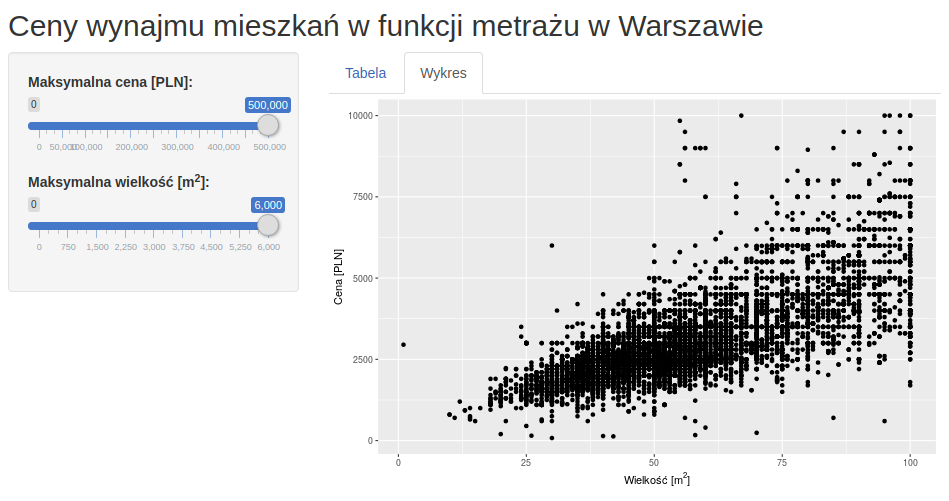

### ui.R

```r
ui <- fluidPage(
  titlePanel("Rental price vs. footage in Warsaw"),
  uiOutput("session_id", style = "position: absolute; top: 2px; right: 2px"),
  sidebarLayout(
    sidebarPanel(
      sliderInput("price_max", "Maximum price [PLN]:",
                  min = 0, max = 5 * 10 ^ 5, value = 5 * 10 ^ 5,
                  step = 2 * 10 ^ 3),
      sliderInput("m2_max", HTML("Maximum footage [m<sup>2</sup>]:"),
                  min = 0, max = 6 * 10 ^ 3, value = 6 * 10 ^ 3, step = 250)
    ),
    mainPanel(
      tabsetPanel(
        tabPanel(
          title = "Table",
          DT::dataTableOutput("tbl")
        ),
        tabPanel(
          title = "Chart",
          plotOutput("plt")
        )
      )
    )
  )
)
```

### server.R

```r
library(DT)
library(tidyverse)
library(shiny)

# Poniższe wywołanie funkcji pozwala poprawnie identyfikować polskie znaki
# Za język w tabeli odpowiada parametr `language` w liście opcji
Sys.setlocale(category = "LC_ALL", locale = "pl")

data <- readRDS("data/gumtree_en.rds") %>%
  filter(between(price, 0, 10^4), between(footage, 0, 10^2))

opts <- list(
  language = list(url = "//cdn.datatables.net/plug-ins/1.10.19/i18n/Polish.json"),
  pageLength = 10,
  searchHighlight = TRUE
)

server <- function(input, output, session) {
  selected_data <- reactive({
    data %>%
      filter(price <= input$price_max & footage <= input$m2_max)
  })

  output$tbl <- DT::renderDataTable({
    selected_data() %>% select(-description, -bathrooms, -smokers, -animals, -words_in_desc)
  }, options = opts)

  output$plt <- renderPlot({
    selected_data() %>%
      ggplot(aes(footage, price)) +
      geom_point() +
      xlab(expression("Footage ["*m^2*"]")) +
      ylab("Price [PLN]")
  })
}
```

# Navbar Panel

Alternative for tabsetPanel, more info available here: https://shiny.rstudio.com/gallery/navbar-example.html

# conditionalPanel

With this function visibility of the panels can be related to values of certain conditions which depends on input values (hence behaviour of an user).

**Function name:**

`conditionalPanel(condition, ...)`

**Arguments**

`condition` - condition which depends on input list, written in Java Script language. Key difference (apart from other obvious syntax issues) is that instead of “$” symbol “.” is used.

`...` - content of the panel

## Example

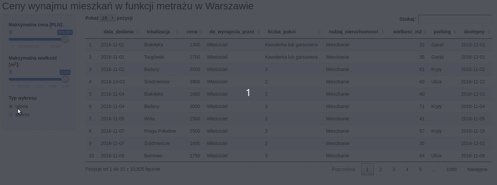

### ui.R

```r
ui <- fluidPage(
  titlePanel("Rental price vs. footage - Warsaw real estate market"),
  uiOutput("session_id", style = "position: absolute; top: 2px; right: 2px"),
  sidebarLayout(
    sidebarPanel(
      width = 2,
      sliderInput("price_max", "Maximum price [PLN]:",
                  min = 0, max = 5 * 10 ^ 5, value = 5 * 10 ^ 5,
                  step = 2 * 10 ^ 3),
      sliderInput("m2_max", HTML("Maximum footage [m<sup>2</sup>]:"),
                  min = 0, max = 6 * 10 ^ 3, value = 6 * 10 ^ 3, step = 250),
      radioButtons("type_chart", "Type of visualisation", choices = c("table", "chart"))
    ),
    mainPanel(
      width = 10,
      conditionalPanel(
        "input.type_chart == 'table'",
        DT::dataTableOutput("tbl")
      ),
      conditionalPanel(
        "input.type_chart == 'chart'",
        plotOutput("plt")
      )
    )
  )
)
```

### server.R

```r
library(DT)
library(tidyverse)
library(shiny)

Sys.setlocale(category = "LC_ALL", locale = "pl")

data <- readRDS("data/gumtree_en.rds") %>%
  filter(between(price, 0, 10^4), between(footage, 0, 10^2))

opts <- list(
  language = list(url = "//cdn.datatables.net/plug-ins/1.10.19/i18n/Polish.json"),
  pageLength = 10,
  searchHighlight = TRUE
)

server <- function(input, output, session) {
    selected_data <- reactive({
      data %>%
        filter(price <= input$price_max & footage <= input$m2_max)
    })

    output$tbl <- DT::renderDataTable({
      selected_data() %>% select(-description, -bathrooms, -smokers, -animals, -words_in_desc)
    }, options = opts)

    output$plt <- renderPlot({
      selected_data() %>%
        ggplot(aes(footage, price)) +
        geom_point() +
        xlab(expression("Footage ["*m^2*"]")) +
        ylab("Price [PLN]")
    })
}
```

# Rules of application arrangement in shiny app

If application have a many elements in graphical interface, arrangement of them is often critical for optimising user experience. Placement of elements in web application is called layout. Until know we used one basic type of layout - `sidebarLayout` in which app was splitted into two panels/parts `sidebar`for widgets and main panel for output.

The raw page is initiated with `fluidPage()`. All in all it is very straightforward. Different layout functions can be mixed (nested) in order to create more complex and fancy layouts, but rememeber this - more simple means better.

Examples are very brief you can test it on any app you like. In place of three dots put any function which returns widget or output from server.

## Example 1: fluidPage with grid layout

One row with two columns, proportion of width 1:2.

```r
fluidPage(
  fluidRow(
    column(width = 4, ...),
    column(width = 8, ...)
  )
)
```

Below two rows, each with two columns with equal width.

```r
fluidPage(
  fluidRow(
    column(width = 6, ...),
    column(width = 6, ...)
  ),
  fluidRow(
    column(width = 6, ...),
    column(width = 6, ...)
  )
)
```

Row splitted into two columns podzielony na dwie kolumny. Second columns splitted into two rows:

```r
fluidPage(
  fluidRow(
    column(width = 8, …),
    column(width = 4,
      fluidRow(column(width = 12, ...)),
      fluidRow(column(width = 12, ...))
    )
  )
)
```

## Example 2: SibebarPanel with grid layout

In this example we used układ layout from previous example to create app which displays chart and table in grid layout, but also has sidebar panel with widgets. This example presents how we can combine functionalities of different layout functions. In fact the can be nested.

### ui.R

```r
ui <- fluidPage(
  fluidRow(
    column(width = 2,
           wellPanel(
             sliderInput("price_max", "Maximum price [PLN]:",
                         min = 0, max = 5 * 10 ^ 5, value = 5 * 10 ^ 5,
                         step = 2 * 10 ^ 3),
             sliderInput("m2_max", HTML("Maximum footage [m<sup>2</sup>]:"),
                         min = 0, max = 6 * 10 ^ 3, value = 6 * 10 ^ 3, step = 250)
           )
    ),
    column(width = 8,
           fluidRow(column(width = 12, DT::dataTableOutput("tbl"))),
           fluidRow(column(width = 12, plotOutput("plt")))
    )
  )
)
```

### server.R

```r
library(DT)
library(tidyverse)
library(shiny)

# This function ensure that polish letters will be identified correctly within
# R session and DT package
opts <- list(
  language = list(url = "//cdn.datatables.net/plug-ins/1.10.19/i18n/Polish.json"),
  pageLength = 10,
  searchHighlight = TRUE
)

Sys.setlocale(category = "LC_ALL", locale = "pl")

data <- readRDS("data/gumtree_en.rds") %>%
  filter(between(price, 0, 10^4), between(footage, 0, 10^2))

server <- function(input, output, session) {
  selected_data <- reactive({
    data %>%
      filter(price <= input$price_max & footage <= input$m2_max)
  })

  output$tbl <- DT::renderDataTable({
    selected_data() %>% select(-description, -bathrooms, -smokers, -animals, -words_in_desc)
  }, options = opts)

  output$plt <- renderPlot({
    selected_data() %>%
      ggplot(aes(footage, price)) +
      geom_point() +
      xlab(expression("Footage ["*m^2*"]")) +
      ylab("Price [PLN]")
  })
}
```

# Package shinydashboard

Excellent addin to shiny, which offers very tidy layout. Authors of the package creates very extensive tutorial here: https://rstudio.github.io/shinydashboard/index.html.